# Sermaye PWT10

Alper Duman

4/26/2021

## Türkiye’de Durum

[Penn World Table](https://www.rug.nl/ggdc/productivity/pwt/) verilerini kullanarak Türkiye’deki sermaye stoğu hakkında bilgi sahibi olmaya çalışacağız.

Bunun için R’da *rmarkdown* adlı kütüphane yazarken gerekli işlemleri de interaktif olarak bu yazı içinde yapmamızı sağlayacak. Verileri işlemek için -şimdilik- iki kütüphane olacak: *pwt10* ve *tidyverse*. Tüm kütüphaneleri *Rstudio* dan kurabilirsiniz. R ve Rstudio ile ilgili tanıtıcı blog yazısını daha ileri bir tarihe bırakıyorum.

Kütüphanelerden *pwt10* verisetini hazır olarak sunuyor. Biz buradan ilk önce sadece Türkiye verilerini alacağız. Bunun için yeni bir kod bloku açarak işlemlerimizi yapıyoruz.

```r
 data("pwt10.0")
 data = force(pwt10.0)
 TR = data[data$country=="Turkey",]
 TR %>% select(rgdpo, emp) %>% head()
```

```
##              rgdpo       emp
## TUR-1950  69852.09  9.448391
## TUR-1951  86501.66  9.580514
## TUR-1952  96740.34  9.715079
## TUR-1953 108137.38  9.856045
## TUR-1954  98750.25 10.007218
## TUR-1955 107954.45 10.171785
```

Önce veriyi çağırdık. Kütüphane verisini kullanılmaya zorladık. Üçüncü komut ile Türkiye verilerini seçtik.Dördüncü komut *tidyverse* kütüphanesinin zincir (pipe) kısayolu olan “%>%” ifadesini içeriyor. Baştaki verisetini komutların içine yeniden yazmak gerekmiyor böylece. “rgdpo” 2017 yılı dolar fiyatlarıyla reel GSYH’yı “emp” ise toplam istihdamı gösteriyor.

Verilere başarıyla ulaştığımıza göre artık sermaye stok değişkenlerine odaklanabiliriz.

- cn : Satınalma paritesiyle cari sermaye stoğu (2017 ABD milyon dolar) [Capital stock at current PPPs (in million 2017 USD)].
- ck : Satınalma paritesiyle sermaye kullanım Endeksi (ABD=1) [Capital services levels at current PPPs (USA = 1)]
- rnna : Sabit fiyatlarla reel sermaye stoğu (2017 ABD milyon dolar) [Capital stock at constant 2017 national prices (in million 2017 USD)}
- rkna : Sabit fiyatlarla reel sermaye kullanım endeksi (2017=1) [Capital services at constant 2017 national prices (2017 = 1)]
- irr : Sermayenin reel içsel getirisi [Real internal rate of return]
- delta : Sermaye stoğunun ortalama yıpranma oranı [Average depreciation rate of the capital stock]

İlk grafik “rnna” yani sabit 2017 dolar fiyatlarıyla reel sermaye stok verisinin gelişimi olacak. Bunun için yine bir kod bloku açalım ve *tidyverse* kütüphanesinden *ggplot* komutundan yararlanalım. Grafiği sermaye stok değişkeninin logaritmasını alarak çizdirince eğim bize büyüme hızını veriyor. Bu da bize sermaye birikiminde büyük kırılmalar olup olmadığını daha rahat görme imkanı veriyor.

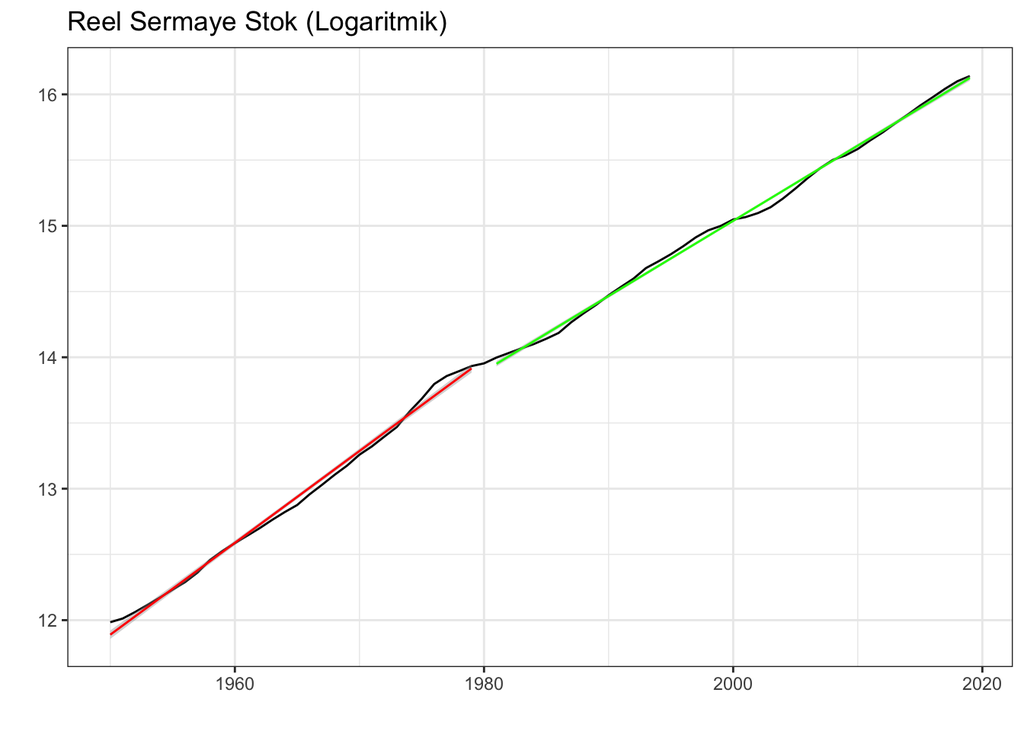

```r
 ggplot(TR, aes(x=year, y=log(rnna))) + geom_line() +
        stat_smooth(method="lm", formula = y ~ x, color="red", ,size=0.5,data = TR[TR$year<1980, ]) +
        stat_smooth(method="lm", formula = y ~ x, color="green", size=0.5, data = TR[TR$year>1980,] ) +
        labs( title="Reel Sermaye Stok (Logaritmik)", x="", y="") + theme_bw()
```

Görüldüğü gibi reel değerlerle sermaye birikimi 1960’lardan beri neredeyse aynı trend üzerinden ilerliyor gibi gözükse de aslında 1980 sonrası trendinde eğim hafif de olsa düşmüştür. Eğim farklarını kırmızı ve yeşil trend çizgilerinden çıkarabiliriz. Neoliberal dönem sermaye birikim hızının da düştüğü bir dönemdir.

İkinci grafik satınalma gücü paritesine göre cari 2017 dolar fiyatlarıyla sermaye stoğunun yıllar içindeki değişimi olacak.

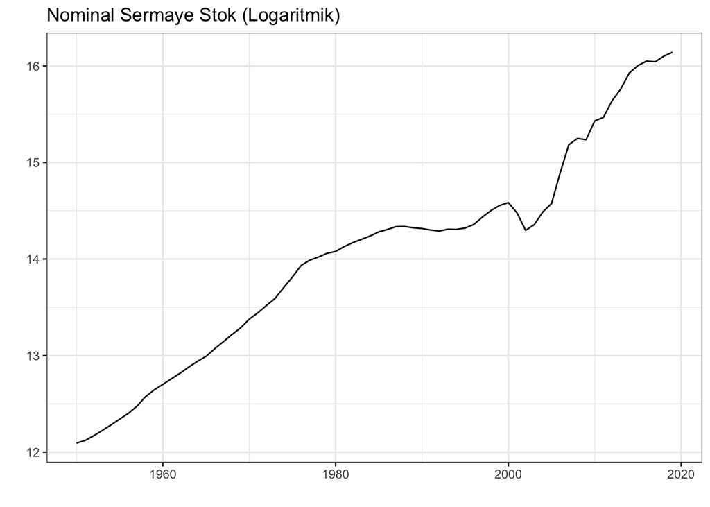

```r
 ggplot(TR, aes(x=year, y=log(cn))) + geom_line() +
        labs( title="Nominal Sermaye Stok (Logaritmik)", x="", y="") + theme_bw()
```

## Başka Ülkelerle Karşılaştırma

Güney Kore ve Almanya’yı karşılaştırmak için seçiyoruz.

```r
 data("pwt10.0")
 data = force(pwt10.0)
 TRDEUKOR = data %>% filter(isocode %in% c("TUR", "KOR", "DEU"))
 TRDEUKOR %>% select(rgdpo, emp) %>% head()
```

```
##             rgdpo      emp
## DEU-1950 358992.5 30.85581
## DEU-1951 397295.1 31.43651
## DEU-1952 433856.8 32.02428
## DEU-1953 471209.0 32.83585
## DEU-1954 512084.1 33.83582
## DEU-1955 583498.6 34.94468
```

Verisetini oluşturabidik sanırım. Şimdi üç ülke için reel sermaye stok verisinin seyrini grafik haline getiriyoruz.

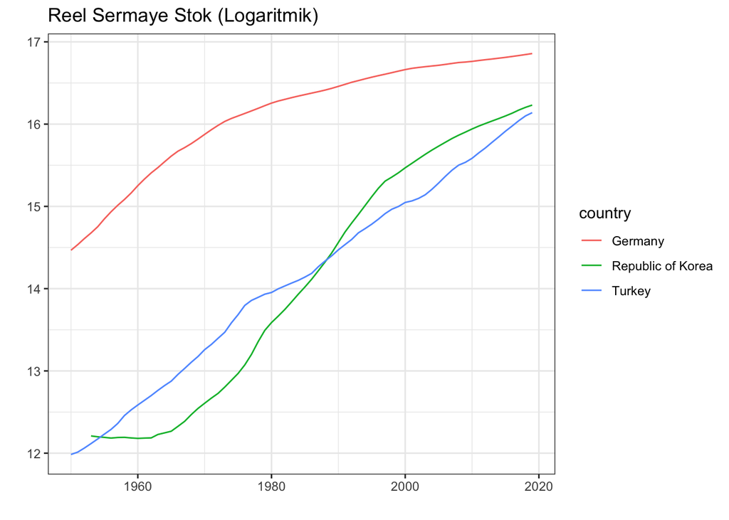

```r
TRDEUKOR %>%
     ggplot(aes(x=year, y=log(rnna), group=country, color=country)) + geom_line()  +
    labs( title="Reel Sermaye Stok (Logaritmik)", x="", y="") + theme_bw()
```

```r
TRDEUKOR %>% filter(isocode %in% c("TUR", "KOR")) %>% filter(year %in% c(1975,1985, 1995)) %>%
    select(rgdpo,emp)
```

```
##              rgdpo      emp
## KOR-1975  159092.9 11.78826
## KOR-1985  304198.5 15.05229
## KOR-1995 1015350.4 20.61784
## TUR-1975  357440.3 12.48905
## TUR-1985  477927.2 15.46264
## TUR-1995  644114.8 19.40966
```

Görüldüğü gibi Güney Kore sermaye birikimi sayesinde 20 yıl içinde GSYH’si Türkiye’nin yarısı kadar bir ekonomiden Türkiye’ye fark atar bir düzeye (Türkiye GSYH’nın 1.5 katından fazlası) gelmiş ve dahası çalışan sayısında da Türkiye’yi geçmiştir.

Son olarak “irr” sermayenin reel içsel getiri oranlarını karşılaştıralım.

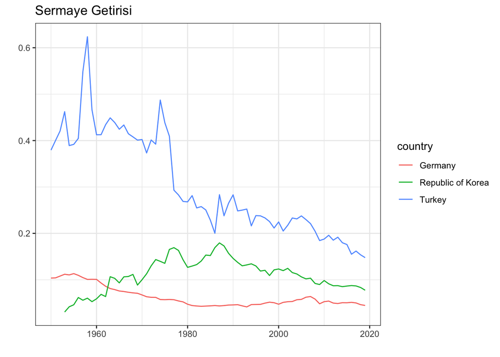

```r
TRDEUKOR %>%
     ggplot(aes(x=year, y=irr, group=country, color=country)) + geom_line()  +
    labs( title="Sermaye Getirisi", x="", y="") + theme_bw()
```

İşte büyük bilmece (puzzle) burada karşımıza çıkıyor. Eğer sermaye getirisi Türkiye’de en yüksekse neden sermaye sahipleri (kapitalistler) sermaye birikimini yeterince artırmıyorlar?

Bu sorunun yanıtını bilimsel olarak verebilen doktora tez derecesini alabilir benden :)